# Climate and Development

Carolina Torreblanca

University of Pennsylvania

**Global Development**: Intermediate Topics in Politics, Policy, and Data

PSCI 3200 - Spring 2026

## Agenda

1. Climate and Development
2. Dell, Jones & Olken (2012)
3. Interpreting Logged Variables

## Deadlines

- **Expanded Research Design** due Wednesday, April 15 by 11:59pm via Slack
  - Make sure your html renders properly and you can see the plots if you open it on a web browser!

# Climate and Development

## The Planet Is Warming

[figure not shown]

## Who Caused It

[figure not shown]

## Should Climate Change Affect Development?

- **Agriculture**: crop yields fall above optimal temperature thresholds
- **Labor productivity**: heat stress reduces output, especially outdoor and manual work
- **Health**: heat illness, expanded disease vectors (malaria, dengue)
- **Conflict**: resource scarcity increases stress and violence
- **Infrastructure**: extreme weather destroys capital

## Who Suffers

[figure not shown]

# Dell, Jones & Olken (2012)

## Hot Countries Are Poor

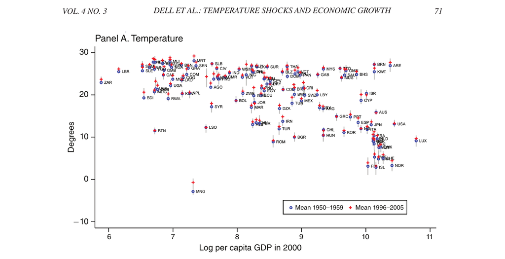

## What Do You Notice?

- Hotter places tend to be poorer. Does that mean heat *causes* poverty?
- What else differs between Nigeria and Norway besides temperature?
- Colonization history, institutions, geography, disease burden, trade access…
- The cross-country pattern cannot isolate the effect of temperature

## Theory

If temperature does affect growth, where would we expect to see it most?

- Places with less capacity to adapt: rain-fed agriculture, weak health systems, fragile institutions
- So … poor countries

## Data and Model

$$\Delta \ln y_{it} = \beta_1 T_{it} + \beta_2 P_{it} + \alpha_i + \gamma_t + \epsilon_{it}$$

- $T_{it}$: mean temperature in country $i$, year $t$, relative to that country’s mean over the full sample (1950–2003)
- $\alpha_i$: country fixed effects
- $\gamma_t$: year fixed effects

## The Identification Strategy

- Country and Year FE absorb everything time-invariant for the country and year including “climate”
- $T_{it}$ measures was this year unusually hot *for this country*? **Weather**
- **Identification assumption:** conditional on country and year FE, year-to-year temperature fluctuations are uncorrelated with other determinants of GDP growth (i.e., $T_{it}$ is exogenous)

## What the Assumption Allows and Forbids

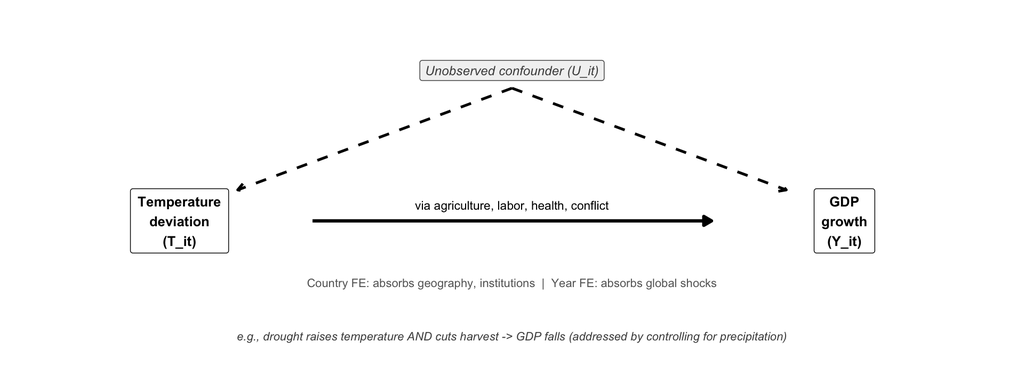

## Reading the Table

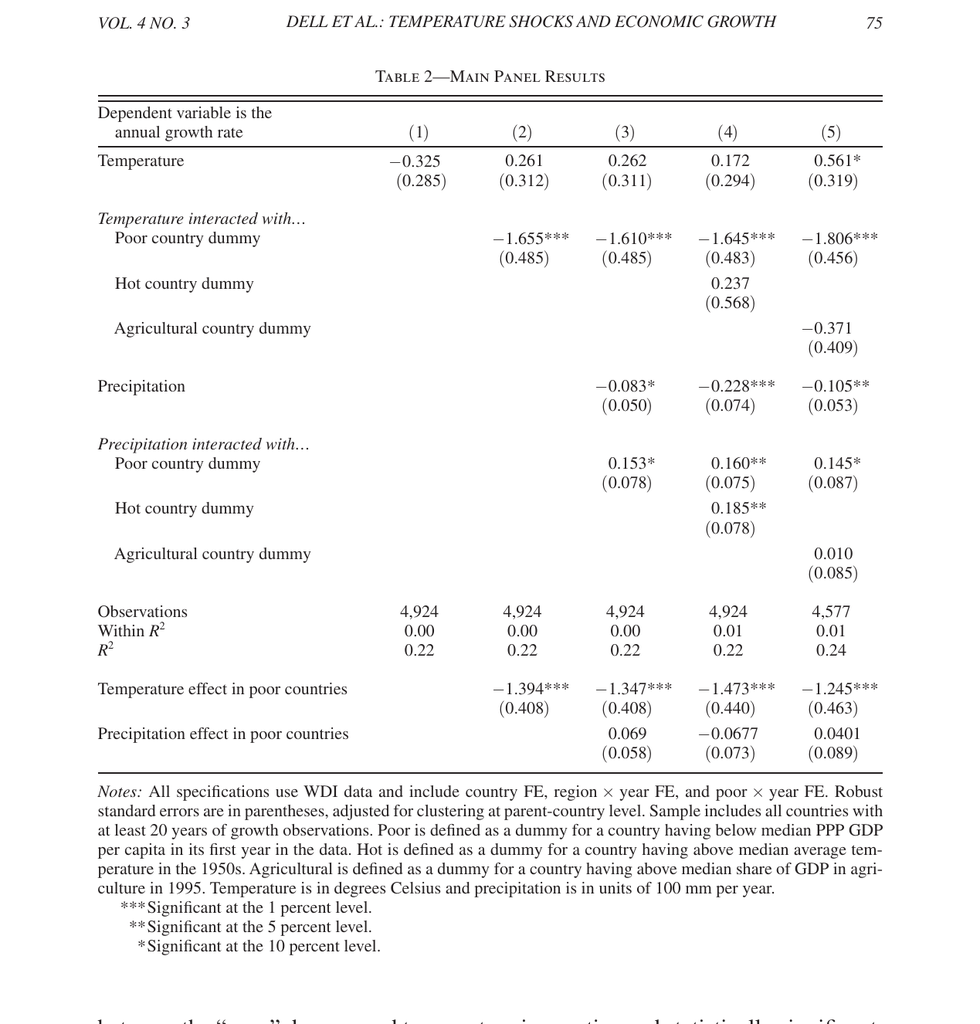

Col (1): no effect on average across all countries.

Col (2): temperature interacted with a poor country dummy. Large and significant (-1.655***).

Marginal effect in poor countries: β_temp + β_interaction = **-1.4pp**. Same logic as `slopes()`.

## What the Paper Argues

- The rich-poor asymmetry suggests climate change will widen global inequality
- Historical emissions came overwhelmingly from rich countries; damages fall on poor ones
- These are effects on *growth rates*, not levels; compounding matters enormously
- A 1.3pp drag sustained over decades means massive foregone development
- Adaptation is possible but requires investment poor countries cannot self-finance

# Interpreting Logged Variables

## Why Log? Reason 1: Skewed Distributions

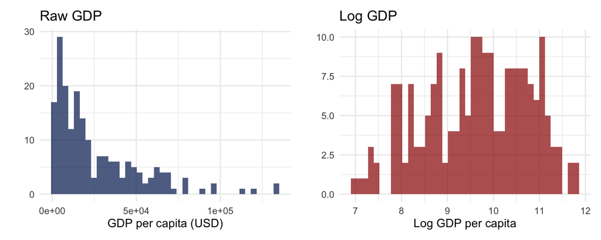

## Why Log? Reason 2: A One-Unit Increase Is Not the Same

**From $403 to $1,097**

- Log distance: **1 unit**
- Dollar jump: $694

**From $22,026 to $59,874**

- Log distance: **1 unit**
- Dollar jump: $37,848

A $700 raise is *a lot* if you earn $400. Not so much if you earn $40,000. Log GDP measures gains *proportionally*.

## Log Scale vs. Dollar Scale

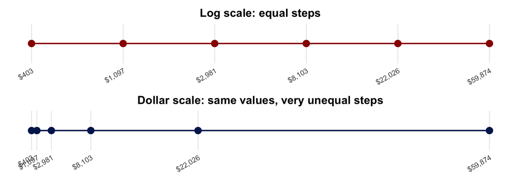

- **Log**: proportional changes matter (income, GDP, population)
- **Levels**: absolute changes matter (temperature, vote share)
- Modeling choice: Dell logs GDP, not temperature

## Caution: Coefficients Mean Something Different

The familiar reading: $\hat{\beta}$ = “a one-unit increase in $X$ raises $Y$ by $\hat{\beta}$ units”

**When $Y$ is $\ln Y$:** $\hat{\beta} \times 100 \approx$ % change in $Y$

**When $Y$ is $\Delta \ln Y$ (already a growth rate):** $\hat{\beta}$ is directly a percentage point change

Interpretation also changes if $X$ is logged